# RNN For Text Classification

RNN is a particularly helpful tool for text classification. Here I will describe how to use it.

```python
#Set-up
import tensorflow_datasets as tfds
import tensorflow as tf
```

```python
#setting up Matplotlib to plot graphs
import matplotlib.pyplot as plt
def plot_graphs(history,metric):
  plt.plot(history.history[metric])
  plt.plot(history.history['val_' + metric],'')
  plt.xlabel("Epochs")
  plt.ylabel(metric)
  plt.legend([metric, 'val_'+metric])
  plt.show()
```

```python
#Loading dataset
dataset,info = tfds.load('imdb_reviews/subwords8k',with_info = True, as_supervised = True)
train_dataset , test_dataset = dataset['train'],dataset['test']
```

```
Downloading and preparing dataset imdb_reviews/subwords8k/1.0.0 (download: 80.23 MiB, generated: Unknown size, total: 80.23 MiB) to /root/tensorflow_datasets/imdb_reviews/subwords8k/1.0.0...
```

```
Shuffling and writing examples to /root/tensorflow_datasets/imdb_reviews/subwords8k/1.0.0.incompleteHCU3RH/imdb_reviews-train.tfrecord
```

```
Shuffling and writing examples to /root/tensorflow_datasets/imdb_reviews/subwords8k/1.0.0.incompleteHCU3RH/imdb_reviews-test.tfrecord
```

```
Shuffling and writing examples to /root/tensorflow_datasets/imdb_reviews/subwords8k/1.0.0.incompleteHCU3RH/imdb_reviews-unsupervised.tfrecord
```

```
Dataset imdb_reviews downloaded and prepared to /root/tensorflow_datasets/imdb_reviews/subwords8k/1.0.0. Subsequent calls will reuse this data.
```

This dataset is almost custom made and very clean in reality one shouldn't expect anything even close to this but its still a good excercise to start with the very simple ones

```python
encoder = info.features['text'].encoder #info contains the encoder
```

```python
print('Vocabulary size: ' + str(encoder.vocab_size))
```

```
Vocabulary size: 8185
```

Let's see how this text encoder works

```python
sample_string = 'I am Ironman'
encoded_string = encoder.encode(sample_string)
print('Encoded string is {}'.format(encoded_string))

original_string = encoder.decode(encoded_string)
print('The original string: "{}"'.format(original_string))
```

```
Encoded string is [12, 258, 7862, 223]
The original string: "I am Ironman"
```

Few takeaway points here is:

1. We are using word encoder here not letter
2. But as you will see in the next chunk its not direct transform, its a bit more complicated
3. Our encoder is perfectly inverse-map-able

```python
for index in encoded_string:
  print('{} ----> {}'.format(index,encoder.decode([index])))
```

```
12 ----> I
258 ----> am
7862 ----> Iron
223 ----> man
```

### Prepare the Data for Training

Next create batches of these encoded strings, we will pad the sequences to the length of the longest string in the batch

```python
BUFFER_SIZE = 10000
BATCH_SIZE = 64
```

```python
train_dataset = train_dataset.shuffle(BUFFER_SIZE)
train_dataset = train_dataset.padded_batch(BATCH_SIZE)
test_dataset = test_dataset.padded_batch(BATCH_SIZE)
```

### Creating the Model

We will build a sequential model and start with an embedding layer. An embedding layer stores one vector per word. When called, it converts the sequences of word indices to sequences of vectors. These vectors are trainable. After training on sufficient amount of data , words with similar meanings often have similar vectors.

This index-lookup is much more efficient than the equivalent operation of passing a one-hot encoded vector through a dense layer, but again context matters

A RNN processes sequence input by iterating through the elements. RNNs pass the outputs from one timestep to their input - and then to the next.

The Bidirectional wrapper can also be used with an RNN layer. This propagates the input forward and backwards through the RNN layer and then concatenates the output. This helps the RNN to learn long range dependencies.

```python
model = tf.keras.Sequential([
    tf.keras.layers.Embedding(encoder.vocab_size,64),
    tf.keras.layers.Bidirectional(tf.keras.layers.LSTM(64)),
    tf.keras.layers.Dense(64,activation = 'relu'),
    tf.keras.layers.Dense(1)
])
```

```python
model.compile(loss = tf.keras.losses.BinaryCrossentropy(from_logits = True),
              optimizer = tf.keras.optimizers.Adam(1e-4),
              metrics = ['accuracy'])
```

```python
history = model.fit(train_dataset,epochs = 10, validation_data = test_dataset, validation_steps = 30)
```

```python
test_loss , test_acc = model.evaluate(test_dataset)
print("Test Loss: {}".format(test_loss))
print("Test Accuracy: {}".format(test_acc))
```

```
Test Loss: 0.41573604941368103
Test Accuracy: 0.852840006351471
```

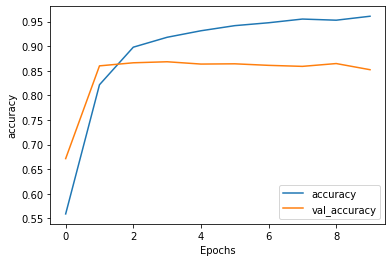

```python
plot_graphs(history,'accuracy')
```

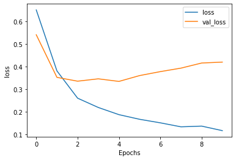

```python
plot_graphs(history,'loss')
```

#### LSTM Model

We will stack two LSTM Layers inside our model

```python
model = tf.keras.Sequential([
  tf.keras.layers.Embedding(encoder.vocab_size,64),
  tf.keras.layers.Bidirectional(tf.keras.layers.LSTM(64, return_sequences=True)),
  tf.keras.layers.Bidirectional(tf.keras.layers.LSTM(32)),
  tf.keras.layers.Dense(64,activation='relu'),
  tf.keras.layers.Dropout(0.5),
  tf.keras.layers.Dense(1)
])
```

```python
model.summary()
```

```
Model: "sequential"
_________________________________________________________________
Layer (type)                 Output Shape              Param #
=================================================================
embedding (Embedding)        (None, None, 64)          523840
_________________________________________________________________
bidirectional (Bidirectional (None, None, 128)         66048
_________________________________________________________________
bidirectional_1 (Bidirection (None, 64)                41216
_________________________________________________________________
dense (Dense)                (None, 64)                4160
_________________________________________________________________
dropout (Dropout)            (None, 64)                0
_________________________________________________________________
dense_1 (Dense)              (None, 1)                 65
=================================================================
Total params: 635,329
Trainable params: 635,329
Non-trainable params: 0
_________________________________________________________________
```

```python
model.compile(loss = tf.keras.losses.BinaryCrossentropy(from_logits=True),
              optimizer = tf.keras.optimizers.Adam(1e-4),
              metrics = ['accuracy'])
```

```python
history = model.fit(train_dataset,epochs = 10, validation_data = test_dataset, validation_steps=30)
```